# chapter 13-1HW-1

Min-Yao

2020/1/10

## 13.7. Practice

###Easy.

### 12E1. Which of the following priors will produce more shrinkage in the estimates? (a) αtank ∼ Normal(0, 1); (b) αtank ∼ Normal(0, 2).

> I think (a) will produce more shrinkage in the estimates, as it is more ‘regularising’(narrow because of lower sigma), thus I expect it forces estimates to be shifted to the mean more than (b). It results in stronger shrinkage.

### 12E2. Make the following model into a multilevel model.

y i ∼ Binomial(1, p i) logit(p i) = αgroup[i] + βxi αgroup ∼ Normal(0, 10) β ∼ Normal(0, 1)

> multilevel model

y_i ~ Binomial(1,p_i) logit(p_i) = a[i] + beta*x_i αgroup ∼ Normal(α_bar, sigma) α_bar ~ Normal(0, 10) sigma ~ Exponential(1) β ∼ Normal(0, 1)

### 12E3. Make the following model into a multilevel model.

y i ∼ Normal(µi, σ) µi = αgroup[i] + βx i αgroup ∼ Normal(0, 10) β ∼ Normal(0, 1) σ ∼ HalfCauchy(0, 2)

> multilevel model

y i ∼ Normal(µi, σ) µi = αgroup[i] + βx i αgroup ∼ Normal(α_bar, sigma) α_bar ~ Normal(0, 10) sigma ~ Exponential(1) β ∼ Normal(0, 1) σ ∼ HalfCauchy(0, 2)

### 12M1. Revisit the Reed frog survival data, data(reedfrogs), and add the predation and size treatment variables to the varying intercepts model. Consider models with either main effect alone, both main effects, as well as a model including both and their interaction. Instead of focusing on inferences about these two predictor variables, focus on the inferred variation across tanks. Explain why it changes as it does across models.

```r
## R code 13.1
library(rethinking)
data(reedfrogs)
d <- reedfrogs
str(d)
```

```
## 'data.frame':    48 obs. of  5 variables:
##  $ density : int  10 10 10 10 10 10 10 10 10 10 ...
##  $ pred    : Factor w/ 2 levels "no","pred": 1 1 1 1 1 1 1 1 2 2 ...
##  $ size    : Factor w/ 2 levels "big","small": 1 1 1 1 2 2 2 2 1 1 ...
##  $ surv    : int  9 10 7 10 9 9 10 9 4 9 ...
##  $ propsurv: num  0.9 1 0.7 1 0.9 0.9 1 0.9 0.4 0.9 ...
```

```r
head(d)
```

```
##   density pred  size surv propsurv
## 1      10   no   big    9      0.9
## 2      10   no   big   10      1.0
## 3      10   no   big    7      0.7
## 4      10   no   big   10      1.0
## 5      10   no small    9      0.9
## 6      10   no small    9      0.9
```

```r
# make the tank cluster variable
d$tank <- 1:nrow(d)
d$has_pred<- ifelse(test = d$pred == "pred", yes = 1, no = 0)
d$is_big<- ifelse(test = d$size == "big", yes = 1, no = 0)
str(d)
```

```
## 'data.frame':    48 obs. of  8 variables:
##  $ density : int  10 10 10 10 10 10 10 10 10 10 ...
##  $ pred    : Factor w/ 2 levels "no","pred": 1 1 1 1 1 1 1 1 2 2 ...
##  $ size    : Factor w/ 2 levels "big","small": 1 1 1 1 2 2 2 2 1 1 ...
##  $ surv    : int  9 10 7 10 9 9 10 9 4 9 ...
##  $ propsurv: num  0.9 1 0.7 1 0.9 0.9 1 0.9 0.4 0.9 ...
##  $ tank    : int  1 2 3 4 5 6 7 8 9 10 ...
##  $ has_pred: num  0 0 0 0 0 0 0 0 1 1 ...
##  $ is_big  : num  1 1 1 1 0 0 0 0 1 1 ...
```

```r
dat <- list(
    S = d$surv,
    N = d$density,
    P = d$has_pred,
    B = d$is_big,
    tank = d$tank )

str(dat)
```

```
## List of 5
##  $ S   : int [1:48] 9 10 7 10 9 9 10 9 4 9 ...
##  $ N   : int [1:48] 10 10 10 10 10 10 10 10 10 10 ...
##  $ P   : num [1:48] 0 0 0 0 0 0 0 0 1 1 ...
##  $ B   : num [1:48] 1 1 1 1 0 0 0 0 1 1 ...
##  $ tank: int [1:48] 1 2 3 4 5 6 7 8 9 10 ...
```

```r
## R code 13.3
m13.2 <- ulam(
    alist(
        S ~ dbinom( N , p ) ,
        logit(p) <- a[tank] ,
        a[tank] ~ dnorm( a_bar , sigma ) ,
        a_bar ~ dnorm( 0 , 1.5 ) ,
        sigma ~ dexp( 1 )
    ), data=dat , chains=4 , log_lik=TRUE )
precis(m13.2)
```

```
## 48 vector or matrix parameters hidden. Use depth=2 to show them.
```

```
##           mean        sd     5.5%    94.5%    n_eff      Rhat
## a_bar 1.343276 0.2498722 0.953885 1.739945 2576.447 0.9999294
## sigma 1.621151 0.2177920 1.310735 2.000157 1706.487 1.0007124
```

```r
## R code 13.3+size
m13.2.size <- ulam(
    alist(
        S ~ dbinom( N , p ) ,
        logit(p) <- a[tank] + b_size*B,
        a[tank] ~ dnorm( a_bar , sigma ) ,
        a_bar ~ dnorm( 0 , 1.5 ) ,
        sigma ~ dexp( 1 ),
        b_size ~ dnorm(0, 1)
    ), data=dat , chains=4 , log_lik=TRUE )
precis(m13.2.size)
```

```
## 48 vector or matrix parameters hidden. Use depth=2 to show them.
```

```
##              mean        sd       5.5%     94.5%     n_eff     Rhat
## a_bar   1.5040163 0.3343518  0.9755077 2.0290706  337.6007 1.006324
## sigma   1.6173081 0.2128499  1.3016349 1.9916125 1174.3123 1.002897
## b_size -0.3126275 0.4440175 -1.0015139 0.3968781  226.5733 1.011385
```

```r
compare(m13.2, m13.2.size)
```

```
##                WAIC       SE    dWAIC       dSE    pWAIC    weight
## m13.2      200.2957 7.216306 0.000000        NA 21.02106 0.6522994
## m13.2.size 201.5540 7.385117 1.258324 0.9940372 21.61621 0.3477006
```

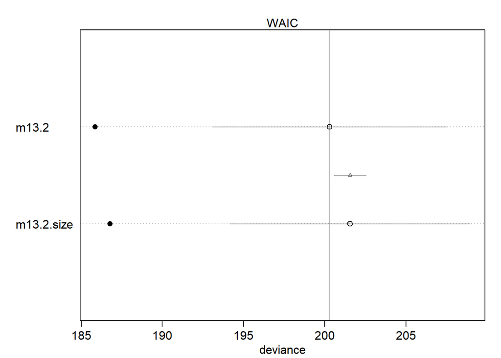

```r
plot(compare(m13.2, m13.2.size))
```

```r
## R code 13.3+predation
m13.2.predation <- ulam(
    alist(
        S ~ dbinom( N , p ) ,
        logit(p) <- a[tank] + b_predation*P,
        a[tank] ~ dnorm( a_bar , sigma ) ,
        a_bar ~ dnorm( 0 , 1.5 ) ,
        sigma ~ dexp( 1 ),
        b_predation ~ dnorm(0, 1)
    ), data=dat , chains=4 , log_lik=TRUE )
precis(m13.2.predation)
```

```
## 48 vector or matrix parameters hidden. Use depth=2 to show them.
```

```
##                   mean        sd      5.5%     94.5%    n_eff     Rhat
## a_bar        2.5195011 0.2426035  2.139335  2.908097 212.4949 1.007943
## sigma        0.8439002 0.1485636  0.627333  1.103137 429.3401 1.011406
## b_predation -2.3970551 0.3086733 -2.868913 -1.875354 177.5970 1.007080
```

```r
compare(m13.2, m13.2.predation)
```

```
##                     WAIC       SE    dWAIC      dSE    pWAIC    weight
## m13.2.predation 198.2870 8.793561 0.000000       NA 18.96099 0.7319067
## m13.2           200.2957 7.216306 2.008636 5.326986 21.02106 0.2680933
```

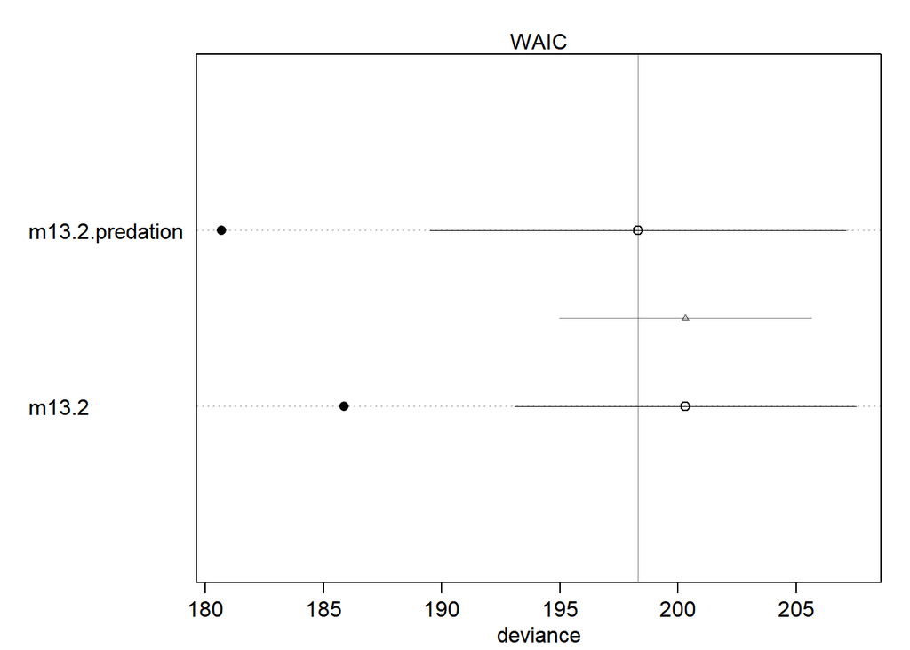

```r
plot(compare(m13.2, m13.2.predation))
```